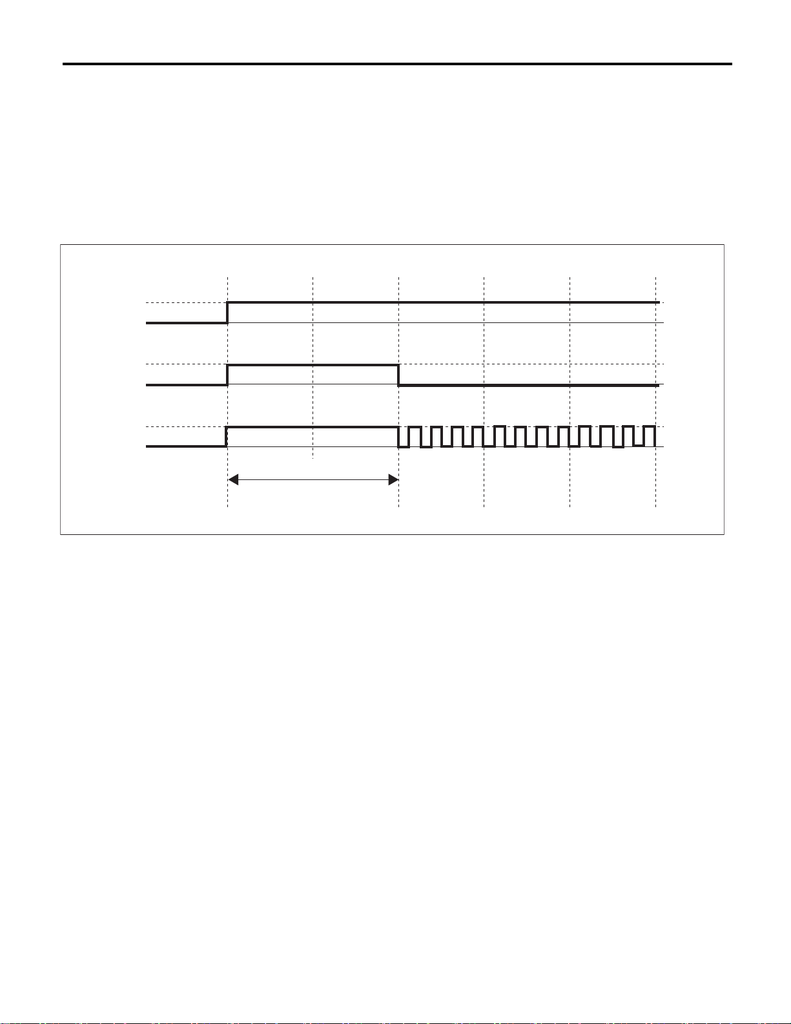

6MT(diag)-14

AWD Warning Light Display

MANUAL TRANSMISSION AND DIFFERENTIAL (DIAGNOSTICS)

11.AWD Warning Light Display

A: OPERATION

AWD light blinks when a fault occurs in AWD.

• At normal condition

After the ignition switch is turned to ON, AWD light illuminates for 2 seconds.

• When malfunction is detected

AWD light blinks at 2 Hz when any of the following malfunctions are detected with the ignition switch ON.

1. When tire with different diameter is installed.

2. When air pressure of any of four tires is excessively low.

If the AWD light does not illuminate, or illumination patterns are not as above, check the AWD light circuit.

<Ref. to 6MT(diag)-15, INSPECTION, AWD Warning Light Display.>

(A) Ignition switch condition

(1) At normal condition (2) When malfunction is detected

MT-03186

(1)

OFF

ON

(2)

(A)

OFF

OFF

2 sec.

Illuminate

Illuminate

[figure not shown]

6MT(diag)-15

AWD Warning Light Display

MANUAL TRANSMISSION AND DIFFERENTIAL (DIAGNOSTICS)

B: INSPECTION

DIAGNOSIS:

• Defective CAN communication

• DCCD control module malfunction

• Combination meter malfunction

TROUBLE SYMPTOM:

• When the ignition switch is turned to ON, the AWD light does not illuminate.

• AWD light illuminates after 2 seconds have elapsed after turning the ignition switch to ON.

• AWD light starts blinking right after 2 seconds have elapsed after turning the ignition switch to ON.

Step Check Yes No

1 CHECK AWD LIGHT.

Turn the ignition switch to ON.

Does AWD light illuminate for 2

seconds after turning the igni-

tion switch to ON?

Go to step 2. Perform the self-

diagnosis of com-

bination meter.

<Ref. to IDI-6,

SELF-DIAGNO-

SIS DISPLAY

MODE, OPERA-

TION, Combina-

tion Meter

System.>

2 CHECK AWD LIGHT.

1) Turn the ignition switch to OFF.

2) Turn the ignition switch to ON.

Does AWD light go off after two

seconds have elapsed after

turning the ignition switch to

ON?

Current condition

is normal. Go back

to Basic Diagnostic

Procedure. <Ref.

to 6MT(diag)-2,

Basic Diagnostic

Procedure.>

Go to step 3.

3 CHECK DTC.

Read the DTC of DCCD using the Subaru

Select Monitor.

Is DTC displayed? Perform the diag-

nosis according to

DTC.

Go to step 4.

4 CHECK COMBINATION METER.

Perform the self-diagnosis of combination

meter. <Ref. to IDI-6, SELF-DIAGNOSIS DIS-

PLAY MODE, OPERATION, Combination

Meter System.>

Is there any trouble with the

combination meter?

Repair the combi-

nation meter.

Replace the DCCD

control module.

<Ref. to

6MT(TY85)-36,

Driver’s Control

Center Differential

Control Module.>